# LessonAndLab16

Shangjun Jiang

July 6, 2016

## Packages

In this lab, you’ll need the following packages:

- xml2
- ggplot2
- lubridate
- stringr
- dplyr
- tidyr

## xml2

`xml2` is a wrapper around the `C` library `libxml2`. In other words, it’s an `R` package that calls on functions from the `C` language. Today, we’ll be looking at a handful of functions from this package:

| Function | Description |
| --- | --- |
| `read_xml` | reads in xml data - can be a file, link, or literal string |
| `xml_attr` | retrieves all attributes of a given name from a nodeset |
| `xml_find_all` | finds all nodes fulfilling xpath criteria |
| `xml_children` | returns a nodeset of all the children of the supplied node |
| `xml_parent` | returns a node of the immediate parent of the supplied node |
| `xml_root` | returns the root of an xml document |
| `xml_text` | extracts the text nodes of a nodeset |
| `xml_double` | extracts the text nodes of a nodeset as numerical values |
| `xml_integer` | extracts the text nodes of a nodeset as integers |

It’s worth noting that these functions are very easily chained together to form a data pipeline! Hopefully you’ll see this in this lab/lesson.

## Good Data Habits - First Questions

It’s always a good idea to get a feel of your data before you jump into the code. Take a look at the latest exchange rates in XML form at this link:

http://www.ecb.europa.eu/stats/eurofxref/eurofxref-hist-90d.xml

```r
library(xml2)
exchange <- read_xml("http://www.ecb.europa.eu/stats/eurofxref/eurofxref-hist-90d.xml")
```

Examine the structure of the XML. Answer the following questions by inspection (without code):

1. What is the name of the root node? “gesmes” is a namespace. They just allow you to reuse names for different reasons. We won’t worry too much about namespaces in this class.
2. What is the exchange rate for the British pound on June 23? June 24?
3. A good data scientist always puts data into context. What is the importance of the dates in question 2?
4. What are the names of the children of the root element? What attributes do they have?
5. What are the names of the subchildren of the root element? What attributes do they have?

## Reading in the data

Read in the xml data using `read_xml()`, assigning the data to `exrate.xml`. The function can take a URL as its argument.

```r
# <Your Code>
link <- "http://www.ecb.europa.eu/stats/eurofxref/eurofxref-hist-90d.xml"
exrate.xml <- read_xml(link)
```

Run the following line of code to remove the default namespace. We won’t be dealing with them in this class, and they don’t affect much in this document anyways. To access the elements with the “gesmes” prefix, you’ll still have to type the XPath in literally (e.g. `"/gesmes:Envelope"`).

```r
exrate.xml <- xml_ns_strip(exrate.xml)
xml_find_all(exrate.xml, "/gesmes:Envelope")
```

```
## {xml_nodeset (1)}
## [1] <gesmes:Envelope xmlns:gesmes="http://www.gesmes.org/xml/2002-08-01" ...
```

Use `xml_root()` to find the root element of the tree. Assign it to the `exrate_root`.

We’ll extract the exchange rates for the British pound (GBP) as an example. First, we need to understand more about the structure of this XML tree.

Here, we examine the third child of the root node (the first two are not important to our interests—why?). If you were to draw a diagram for this tree, with the following expression, we would be looking at the following node:

Envelope > Cube

```r
first_cube <- xml_children(exrate_root)[[3]]
first_cube
```

```
## {xml_node}
## <Cube>
##  [1] <Cube time="2016-07-06">\n  <Cube currency="USD" rate="1.1069"/>\n  ...
##  [2] <Cube time="2016-07-05">\n  <Cube currency="USD" rate="1.1146"/>\n  ...
##  [3] <Cube time="2016-07-04">\n  <Cube currency="USD" rate="1.1138"/>\n  ...
##  [4] <Cube time="2016-07-01">\n  <Cube currency="USD" rate="1.1135"/>\n  ...
##  [5] <Cube time="2016-06-30">\n  <Cube currency="USD" rate="1.1102"/>\n  ...
##  [6] <Cube time="2016-06-29">\n  <Cube currency="USD" rate="1.109"/>\n   ...
##  [7] <Cube time="2016-06-28">\n  <Cube currency="USD" rate="1.1073"/>\n  ...
##  [8] <Cube time="2016-06-27">\n  <Cube currency="USD" rate="1.0998"/>\n  ...
##  [9] <Cube time="2016-06-24">\n  <Cube currency="USD" rate="1.1066"/>\n  ...
## [10] <Cube time="2016-06-23">\n  <Cube currency="USD" rate="1.1389"/>\n  ...
## [11] <Cube time="2016-06-22">\n  <Cube currency="USD" rate="1.1283"/>\n  ...
## [12] <Cube time="2016-06-21">\n  <Cube currency="USD" rate="1.1314"/>\n  ...
## [13] <Cube time="2016-06-20">\n  <Cube currency="USD" rate="1.1332"/>\n  ...
## [14] <Cube time="2016-06-17">\n  <Cube currency="USD" rate="1.1254"/>\n  ...
## [15] <Cube time="2016-06-16">\n  <Cube currency="USD" rate="1.1174"/>\n  ...
## [16] <Cube time="2016-06-15">\n  <Cube currency="USD" rate="1.123"/>\n   ...
## [17] <Cube time="2016-06-14">\n  <Cube currency="USD" rate="1.1225"/>\n  ...
## [18] <Cube time="2016-06-13">\n  <Cube currency="USD" rate="1.1268"/>\n  ...
## [19] <Cube time="2016-06-10">\n  <Cube currency="USD" rate="1.1304"/>\n  ...
## [20] <Cube time="2016-06-09">\n  <Cube currency="USD" rate="1.1343"/>\n  ...
## ...
```

We can pipe these expressions to look one level down to Envelope > Cube > Cube:

```r
first_time_cube <- exrate_root %>%
  xml_children() %>%
  .[[3]] %>%
  xml_children()
first_time_cube
```

```
## {xml_nodeset (64)}
##  [1] <Cube time="2016-07-06">\n  <Cube currency="USD" rate="1.1069"/>\n  ...
##  [2] <Cube time="2016-07-05">\n  <Cube currency="USD" rate="1.1146"/>\n  ...
##  [3] <Cube time="2016-07-04">\n  <Cube currency="USD" rate="1.1138"/>\n  ...
##  [4] <Cube time="2016-07-01">\n  <Cube currency="USD" rate="1.1135"/>\n  ...
##  [5] <Cube time="2016-06-30">\n  <Cube currency="USD" rate="1.1102"/>\n  ...
##  [6] <Cube time="2016-06-29">\n  <Cube currency="USD" rate="1.109"/>\n   ...
##  [7] <Cube time="2016-06-28">\n  <Cube currency="USD" rate="1.1073"/>\n  ...
##  [8] <Cube time="2016-06-27">\n  <Cube currency="USD" rate="1.0998"/>\n  ...
##  [9] <Cube time="2016-06-24">\n  <Cube currency="USD" rate="1.1066"/>\n  ...
## [10] <Cube time="2016-06-23">\n  <Cube currency="USD" rate="1.1389"/>\n  ...
## [11] <Cube time="2016-06-22">\n  <Cube currency="USD" rate="1.1283"/>\n  ...
## [12] <Cube time="2016-06-21">\n  <Cube currency="USD" rate="1.1314"/>\n  ...
## [13] <Cube time="2016-06-20">\n  <Cube currency="USD" rate="1.1332"/>\n  ...
## [14] <Cube time="2016-06-17">\n  <Cube currency="USD" rate="1.1254"/>\n  ...
## [15] <Cube time="2016-06-16">\n  <Cube currency="USD" rate="1.1174"/>\n  ...
## [16] <Cube time="2016-06-15">\n  <Cube currency="USD" rate="1.123"/>\n   ...
## [17] <Cube time="2016-06-14">\n  <Cube currency="USD" rate="1.1225"/>\n  ...
## [18] <Cube time="2016-06-13">\n  <Cube currency="USD" rate="1.1268"/>\n  ...
## [19] <Cube time="2016-06-10">\n  <Cube currency="USD" rate="1.1304"/>\n  ...
## [20] <Cube time="2016-06-09">\n  <Cube currency="USD" rate="1.1343"/>\n  ...
## ...
```

As we can see, this element is the parent of another node named Cube that has a “time” attribute. In turn, the Cube node with the `time` attribute node is the parent of several other Cube nodes with “currency” and “rate” attributes.

## GBP Nodes - Two Steps, easily piped

First, obtain all of the nodes that have the name “Cube” and an attribute “currency” set to GBP.

We provide `xml_find_all` the root node and the XPath to the nodes we’re interested in. Provide the predicate (“subsetting”) in the XPath expression to locate those Cube nodes with a currency attribute value of “GBP” ##### extract all with the GBP

```r
gbp_nodes = exrate_root %>%
  xml_find_all('//Cube[@currency="GBP"]')
gbp_nodes
```

```
## {xml_nodeset (64)}
##  [1] <Cube currency="GBP" rate="0.853"/>
##  [2] <Cube currency="GBP" rate="0.84997"/>
##  [3] <Cube currency="GBP" rate="0.83905"/>
##  [4] <Cube currency="GBP" rate="0.8383"/>
##  [5] <Cube currency="GBP" rate="0.8265"/>
##  [6] <Cube currency="GBP" rate="0.8255"/>
##  [7] <Cube currency="GBP" rate="0.8272"/>
##  [8] <Cube currency="GBP" rate="0.834"/>
##  [9] <Cube currency="GBP" rate="0.8075"/>
## [10] <Cube currency="GBP" rate="0.76595"/>
## [11] <Cube currency="GBP" rate="0.76793"/>
## [12] <Cube currency="GBP" rate="0.76755"/>
## [13] <Cube currency="GBP" rate="0.77375"/>
## [14] <Cube currency="GBP" rate="0.7877"/>
## [15] <Cube currency="GBP" rate="0.79033"/>
## [16] <Cube currency="GBP" rate="0.79158"/>
## [17] <Cube currency="GBP" rate="0.79478"/>
## [18] <Cube currency="GBP" rate="0.79515"/>
## [19] <Cube currency="GBP" rate="0.7848"/>
## [20] <Cube currency="GBP" rate="0.78438"/>
## ...
```

Now for the second step. 2. Use `xml_attr()` to get the value of the “rate” attribute on those nodes. **Good habit: Take a look at its documentation to see how it works.**

```r
?xml_attr
gbp_rates = gbp_nodes %>%
  xml_attr("rate") %>%   #always return as a string, so need to change it to numeric
  as.numeric()
gbp_rates
```

```
##  [1] 0.85300 0.84997 0.83905 0.83830 0.82650 0.82550 0.82720 0.83400
##  [9] 0.80750 0.76595 0.76793 0.76755 0.77375 0.78770 0.79033 0.79158
## [17] 0.79478 0.79515 0.78480 0.78438 0.78048 0.77880 0.78720 0.77285
## [25] 0.77335 0.77358 0.76185 0.76125 0.76245 0.75970 0.75925 0.76513
## [33] 0.77443 0.77008 0.76585 0.77485 0.78150 0.78800 0.78758 0.78888
## [41] 0.78958 0.78760 0.78998 0.78850 0.78860 0.79284 0.79103 0.78248
## [49] 0.78025 0.77838 0.77475 0.77483 0.77640 0.78335 0.78693 0.79100
## [57] 0.78975 0.79780 0.79575 0.79560 0.79388 0.79840 0.80060 0.80730
```

Note that we can do all of the above in one pipeline

```r
exrate_root %>%
  xml_find_all('//Cube[@currency="GBP"]') %>%
  xml_attr("rate") %>%
  as.numeric()
```

### You try it out

Modify the above method to extract all the time attributes. Make sure your final answer has the right data type. Assign the results to `exrate_times`

```r
# <Your code>
# //Cube/@time
# /Envelop/Cube/Cube[@time]
exrate_time <- xml_find_all(exrate_root, "//Cube[@time]") %>%
  xml_attr("time") %>%
  ymd()
class(exrate_time)
```

```
## [1] "Date"
```

## What’s next?

Now we’ve successfully extracted the exchange rates and dates for the British pound. We can create our first simple plot.

```r
# <Your code>
df <- data.frame(gbp_rates,exrate_time)
str(df)
```

```
## 'data.frame':    64 obs. of  2 variables:
##  $ gbp_rates  : num  0.853 0.85 0.839 0.838 0.827 ...
##  $ exrate_time: Date, format: "2016-07-06" "2016-07-05" ...
```

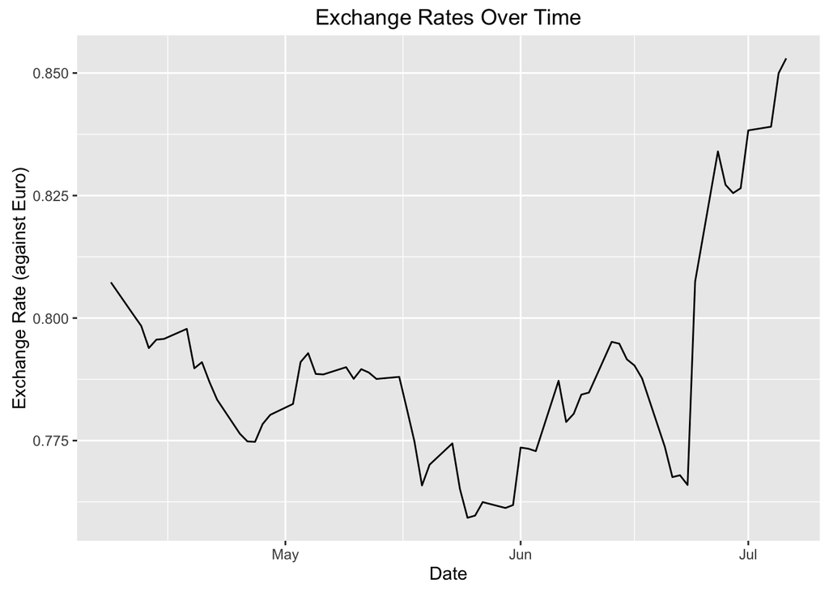

```r
ggplot(df, aes(x=exrate_time,y=gbp_rates)) +
  geom_line() +
  labs(title= "Exchange Rates Over Time",
        x = "Date",
        y = "Exchange Rate (against Euro)")
```

## Extract rates for three other currencies

I gave you an example with the British pound. Now, extract the exchange rates for other currencies and add it to the time series we just created.

Rather than repeating code, we write a helper function to do the extraction. This function takes the XML document and the three letter currency abbreviation as a character string. (Technically the root is the same as the document. You can check this with `identical(exrate_root, exrate.xml)`).

The function should return a numeric vector with the daily exchange rates for the associated currency. Name the function `GetExchangeRates`.

```r
# <Your code>
identical(exrate_root,exrate.xml)
```

```
## [1] TRUE
```

```r
GetExchangeRates <- function (currency){
  dd <- xml_find_all(exrate_root, "//Cube[@time]")
  cc <- xml_find_all(exrate_root, str_c('//Cube[@currency="', currency,'"]'))
  v<- c(as.numeric(xml_attr(cc, "rate")))
  names(v) <- ymd(xml_attr(dd, "time"))
  print(v)
}

GetExchangeRates("USD")
```

```
## 2016-07-06 2016-07-05 2016-07-04 2016-07-01 2016-06-30 2016-06-29
##     1.1069     1.1146     1.1138     1.1135     1.1102     1.1090
## 2016-06-28 2016-06-27 2016-06-24 2016-06-23 2016-06-22 2016-06-21
##     1.1073     1.0998     1.1066     1.1389     1.1283     1.1314
## 2016-06-20 2016-06-17 2016-06-16 2016-06-15 2016-06-14 2016-06-13
##     1.1332     1.1254     1.1174     1.1230     1.1225     1.1268
## 2016-06-10 2016-06-09 2016-06-08 2016-06-07 2016-06-06 2016-06-03
##     1.1304     1.1343     1.1378     1.1348     1.1349     1.1154
## 2016-06-02 2016-06-01 2016-05-31 2016-05-30 2016-05-27 2016-05-26
##     1.1188     1.1174     1.1154     1.1139     1.1168     1.1168
## 2016-05-25 2016-05-24 2016-05-23 2016-05-20 2016-05-19 2016-05-18
##     1.1146     1.1168     1.1215     1.1219     1.1197     1.1279
## 2016-05-17 2016-05-16 2016-05-13 2016-05-12 2016-05-11 2016-05-10
##     1.1318     1.1324     1.1348     1.1389     1.1409     1.1375
## 2016-05-09 2016-05-06 2016-05-05 2016-05-04 2016-05-03 2016-05-02
##     1.1395     1.1427     1.1439     1.1505     1.1569     1.1493
## 2016-04-29 2016-04-28 2016-04-27 2016-04-26 2016-04-25 2016-04-22
##     1.1403     1.1358     1.1303     1.1287     1.1264     1.1263
## 2016-04-21 2016-04-20 2016-04-19 2016-04-18 2016-04-15 2016-04-14
##     1.1355     1.1379     1.1343     1.1306     1.1284     1.1252
## 2016-04-13 2016-04-12 2016-04-11 2016-04-08
##     1.1298     1.1396     1.1390     1.1363
```

```r
# <Your code>
?lapply
currencies<- lapply(c("GBP", "USD", "CAD", "AUD"), GetExchangeRates)
```

```
## 2016-07-06 2016-07-05 2016-07-04 2016-07-01 2016-06-30 2016-06-29
##    0.85300    0.84997    0.83905    0.83830    0.82650    0.82550
## 2016-06-28 2016-06-27 2016-06-24 2016-06-23 2016-06-22 2016-06-21
##    0.82720    0.83400    0.80750    0.76595    0.76793    0.76755
## 2016-06-20 2016-06-17 2016-06-16 2016-06-15 2016-06-14 2016-06-13
##    0.77375    0.78770    0.79033    0.79158    0.79478    0.79515
## 2016-06-10 2016-06-09 2016-06-08 2016-06-07 2016-06-06 2016-06-03
##    0.78480    0.78438    0.78048    0.77880    0.78720    0.77285
## 2016-06-02 2016-06-01 2016-05-31 2016-05-30 2016-05-27 2016-05-26
##    0.77335    0.77358    0.76185    0.76125    0.76245    0.75970
## 2016-05-25 2016-05-24 2016-05-23 2016-05-20 2016-05-19 2016-05-18
##    0.75925    0.76513    0.77443    0.77008    0.76585    0.77485
## 2016-05-17 2016-05-16 2016-05-13 2016-05-12 2016-05-11 2016-05-10
##    0.78150    0.78800    0.78758    0.78888    0.78958    0.78760
## 2016-05-09 2016-05-06 2016-05-05 2016-05-04 2016-05-03 2016-05-02
##    0.78998    0.78850    0.78860    0.79284    0.79103    0.78248
## 2016-04-29 2016-04-28 2016-04-27 2016-04-26 2016-04-25 2016-04-22
##    0.78025    0.77838    0.77475    0.77483    0.77640    0.78335
## 2016-04-21 2016-04-20 2016-04-19 2016-04-18 2016-04-15 2016-04-14
##    0.78693    0.79100    0.78975    0.79780    0.79575    0.79560
## 2016-04-13 2016-04-12 2016-04-11 2016-04-08
##    0.79388    0.79840    0.80060    0.80730
## 2016-07-06 2016-07-05 2016-07-04 2016-07-01 2016-06-30 2016-06-29
##     1.1069     1.1146     1.1138     1.1135     1.1102     1.1090
## 2016-06-28 2016-06-27 2016-06-24 2016-06-23 2016-06-22 2016-06-21
##     1.1073     1.0998     1.1066     1.1389     1.1283     1.1314
## 2016-06-20 2016-06-17 2016-06-16 2016-06-15 2016-06-14 2016-06-13
##     1.1332     1.1254     1.1174     1.1230     1.1225     1.1268
## 2016-06-10 2016-06-09 2016-06-08 2016-06-07 2016-06-06 2016-06-03
##     1.1304     1.1343     1.1378     1.1348     1.1349     1.1154
## 2016-06-02 2016-06-01 2016-05-31 2016-05-30 2016-05-27 2016-05-26
##     1.1188     1.1174     1.1154     1.1139     1.1168     1.1168
## 2016-05-25 2016-05-24 2016-05-23 2016-05-20 2016-05-19 2016-05-18
##     1.1146     1.1168     1.1215     1.1219     1.1197     1.1279
## 2016-05-17 2016-05-16 2016-05-13 2016-05-12 2016-05-11 2016-05-10
##     1.1318     1.1324     1.1348     1.1389     1.1409     1.1375
## 2016-05-09 2016-05-06 2016-05-05 2016-05-04 2016-05-03 2016-05-02
##     1.1395     1.1427     1.1439     1.1505     1.1569     1.1493
## 2016-04-29 2016-04-28 2016-04-27 2016-04-26 2016-04-25 2016-04-22
##     1.1403     1.1358     1.1303     1.1287     1.1264     1.1263
```

[output cut: 33 more lines]

```
##     1.5274     1.5250     1.5228     1.5260     1.5417     1.5397
## 2016-06-02 2016-06-01 2016-05-31 2016-05-30 2016-05-27 2016-05-26
##     1.5516     1.5370     1.5366     1.5504     1.5483     1.5481
## 2016-05-25 2016-05-24 2016-05-23 2016-05-20 2016-05-19 2016-05-18
##     1.5475     1.5597     1.5542     1.5519     1.5563     1.5521
## 2016-05-17 2016-05-16 2016-05-13 2016-05-12 2016-05-11 2016-05-10
##     1.5457     1.5526     1.5579     1.5541     1.5474     1.5486
## 2016-05-09 2016-05-06 2016-05-05 2016-05-04 2016-05-03 2016-05-02
##     1.5544     1.5501     1.5266     1.5379     1.5303     1.5025
## 2016-04-29 2016-04-28 2016-04-27 2016-04-26 2016-04-25 2016-04-22
##     1.4948     1.4906     1.4885     1.4600     1.4587     1.4570
## 2016-04-21 2016-04-20 2016-04-19 2016-04-18 2016-04-15 2016-04-14
##     1.4496     1.4556     1.4547     1.4685     1.4648     1.4610
## 2016-04-13 2016-04-12 2016-04-11 2016-04-08
##     1.4768     1.4882     1.5060     1.5091
```

```r
names(currencies) <- c("GBP", "USD", "CAD", "AUD")
```

Now we are ready to make our plot! Use `do.call` to turn `currencies` into a data frame called `exrate.df`. Also, add a time column using `mutate` and `exrate_times` from earlier. Look at that! No need to do silly subsetting or naming the arguments of `data.frame`.

```r
# <Your code>
exrate.df <- do.call(data.frame, currencies)
row.names(exrate.df)
```

```
##  [1] "2016-07-06" "2016-07-05" "2016-07-04" "2016-07-01" "2016-06-30"
##  [6] "2016-06-29" "2016-06-28" "2016-06-27" "2016-06-24" "2016-06-23"
## [11] "2016-06-22" "2016-06-21" "2016-06-20" "2016-06-17" "2016-06-16"
## [16] "2016-06-15" "2016-06-14" "2016-06-13" "2016-06-10" "2016-06-09"
## [21] "2016-06-08" "2016-06-07" "2016-06-06" "2016-06-03" "2016-06-02"
## [26] "2016-06-01" "2016-05-31" "2016-05-30" "2016-05-27" "2016-05-26"
## [31] "2016-05-25" "2016-05-24" "2016-05-23" "2016-05-20" "2016-05-19"
## [36] "2016-05-18" "2016-05-17" "2016-05-16" "2016-05-13" "2016-05-12"
## [41] "2016-05-11" "2016-05-10" "2016-05-09" "2016-05-06" "2016-05-05"
## [46] "2016-05-04" "2016-05-03" "2016-05-02" "2016-04-29" "2016-04-28"
## [51] "2016-04-27" "2016-04-26" "2016-04-25" "2016-04-22" "2016-04-21"
## [56] "2016-04-20" "2016-04-19" "2016-04-18" "2016-04-15" "2016-04-14"
## [61] "2016-04-13" "2016-04-12" "2016-04-11" "2016-04-08"
```

```r
exrate.df <- mutate(exrate.df, time= row.names(exrate.df))
exrate.df
```

```
##        GBP    USD    CAD    AUD       time
## 1  0.85300 1.1069 1.4419 1.4812 2016-07-06
## 2  0.84997 1.1146 1.4418 1.4902 2016-07-05
## 3  0.83905 1.1138 1.4328 1.4792 2016-07-04
## 4  0.83830 1.1135 1.4390 1.4884 2016-07-01
## 5  0.82650 1.1102 1.4384 1.4929 2016-06-30
## 6  0.82550 1.1090 1.4407 1.4911 2016-06-29
## 7  0.82720 1.1073 1.4438 1.4984 2016-06-28
## 8  0.83400 1.0998 1.4350 1.4857 2016-06-27
## 9  0.80750 1.1066 1.4392 1.4910 2016-06-24
## 10 0.76595 1.1389 1.4517 1.5060 2016-06-23
## 11 0.76793 1.1283 1.4399 1.5033 2016-06-22
## 12 0.76755 1.1314 1.4451 1.5073 2016-06-21
## 13 0.77375 1.1332 1.4520 1.5188 2016-06-20
## 14 0.78770 1.1254 1.4519 1.5234 2016-06-17
```

[output cut: 50 more lines]

Wrangle the data frame to produce the plot below:

```r
# <Your code>
gather(exrate.df,key=rate, value=country, -c(GBP,USD,CAD,AUD))
```

```
##        GBP    USD    CAD    AUD rate    country
## 1  0.85300 1.1069 1.4419 1.4812 time 2016-07-06
## 2  0.84997 1.1146 1.4418 1.4902 time 2016-07-05
## 3  0.83905 1.1138 1.4328 1.4792 time 2016-07-04
## 4  0.83830 1.1135 1.4390 1.4884 time 2016-07-01
## 5  0.82650 1.1102 1.4384 1.4929 time 2016-06-30
## 6  0.82550 1.1090 1.4407 1.4911 time 2016-06-29
## 7  0.82720 1.1073 1.4438 1.4984 time 2016-06-28
## 8  0.83400 1.0998 1.4350 1.4857 time 2016-06-27
## 9  0.80750 1.1066 1.4392 1.4910 time 2016-06-24
## 10 0.76595 1.1389 1.4517 1.5060 time 2016-06-23
## 11 0.76793 1.1283 1.4399 1.5033 time 2016-06-22
## 12 0.76755 1.1314 1.4451 1.5073 time 2016-06-21
## 13 0.77375 1.1332 1.4520 1.5188 time 2016-06-20
## 14 0.78770 1.1254 1.4519 1.5234 time 2016-06-17
```

[output cut: 50 more lines]

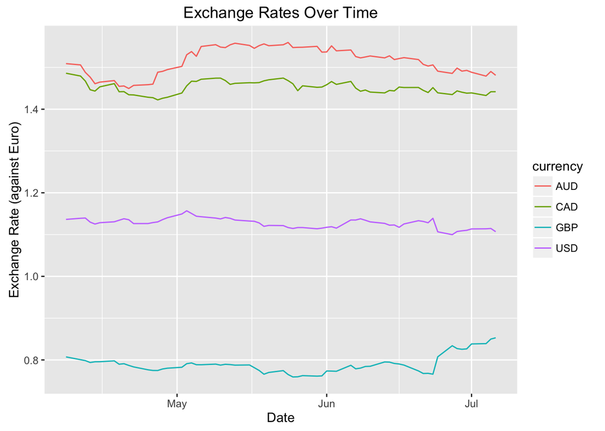

```r
gdf <- gather(exrate.df, currency, rate, -time)
gdf$time<- ymd(gdf$time)

ggplot(gdf,aes(x=time, y=rate)) +
  geom_line(aes(color=currency))+
  labs(title= "Exchange Rates Over Time",
        x = "Date",
        y = "Exchange Rate (against Euro)")
```